# Systemy Decyzyjne 2023/2024

Laboratorium 4 - podstawowe modele predykcyjne

Andrzej Janusz

## Naive Bayes

Jednym z przykładów prostego model predykcyjnego jest *Naive Bayes*.

Twierdzenie Bayesa (w najprostszej postaci):
$$P(Y|X) = P(Y)*P(X|Y) / P(X)$$
U nas $X$ to wielowymiarowa zmienna losowa. Pojedynczy obiekt w danych traktujemy jak jej realizację, czyli pojedynczy obiekt to wektor konkretnych wartości $<x_1, ..., x_N>$. Załóżmy, że każda z wartości $x_1, \ldots, x_N$ ma niezerowe prawdopodobieństwo wystąpienia (czyli w uproszczeniu atrybuty mają wartości symboliczne i każda z tych wartości jest możliwa). $Y$ to u nas decyzja (także zmienna losowa).

Przepisujemy twierdzenia Bayesa:
$$P(Y =
y|X = <x_1, \ldots, x_N>) = \frac{P(Y = y)*P(X = <x_1, \ldots,
x_N>|Y = y)}{P(X = <x_1, \ldots, x_N>)}$$
Teraz “naiwnie” zakladamy, że $<x_1, \ldots, x_N>$ odpowiada realizacji $N$ niezależnych zmiennych losowych $X_1, \ldots, X_N$. Dostajemy:
$$P(Y = y|X = <x_1, \ldots, x_N>) = \frac{P(Y
= y)*P(X_1 = x_1|Y = y)* \ldots *P(X_N = x_N|Y = y)}{P(X1 = x_1)* \ldots
*P(X_N = x_N)}$$
Klasyfikator *Naive Bayes* przypisuje testowanemu obiektowi klasę o najwyższym prawdopodobieństwie a posteriori, czyli tą, dla której iloczyn z licznika powyższego ułamka jest największy. W przypadku, gdy atrybuty przyjmują wartości rzeczywisce (prawdopodobieństwo uzyskania konkretnej wartości jest bliskie 0), wykorzystuje się wartości gęstosci danego rozkładu lub dyskretyzuje dane.

```r
# wczytajmy zabawkowe dane:
dataPath = 'https://raw.githubusercontent.com/pritomzap/CSV-to-ARFF-converter/master/weather_nominal.csv'
data_golf = fread(dataPath, header = TRUE, sep = ',', stringsAsFactors = TRUE)
```

```
 [100%] Downloaded 171 bytes...
```

```r
data_golf
```

| Outlook | Temperature | Humidity | Windy | Play golf |
| --- | --- | --- | --- | --- |
| Rainy | Hot | High | FALSE | No |
| Rainy | Hot | High | TRUE | No |
| Overcast | Hot | High | FALSE | Yes |
| Sunny | Mild | High | FALSE | Yes |
| Sunny | Cool | Normal | FALSE | Yes |
| Sunny | Cool | Normal | TRUE | No |
| Overcast | Cool | Normal | TRUE | Yes |
| Rainy | Mild | High | FALSE | No |
| Rainy | Cool | Normal | FALSE | Yes |
| Sunny | Mild | Normal | FALSE | Yes |

[output cut: 4 more lines]

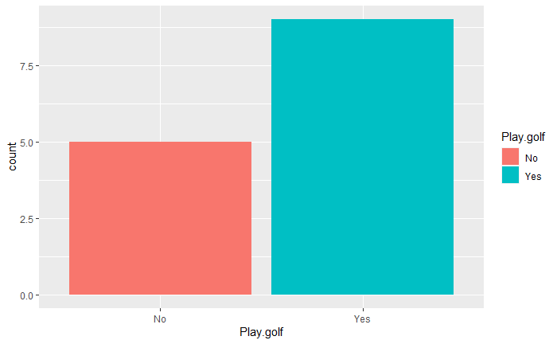

```r
# naprawmy nazwę ostatniej kolumny
setnames(data_golf, "Play golf", "Play.golf")

# zapisuję wartości decyzji na osobny wektor
clsVec = data_golf[, Play.golf]

# żeby lepiej kontrolować eksperyment zainicjujmy generator liczb pseudolosowych
set.seed(123)

# wyznaczmy przykładowy podzbiór treningowy:
trainingIdx = sample(nrow(data_golf), 7)

# definiujemy nowe zadanie predykcji
golf_task <- TaskClassif$new(id = "golf_dt", backend = data_golf,
                             target = "Play.golf")

# wizualizacja danych
ggplot(data_golf, aes(x = Play.golf)) + geom_bar(aes(fill = Play.golf))
```

```r
# stwórzmy model Naive Bayes
nb_learner <- lrn("classif.naive_bayes")
# możemy sprawdzić aktualne ustawienia parametrów modelu
nb_learner$param_set
```

```
<ParamSet>
```

| id | class | lower | upper | nlevels | default | value |
| --- | --- | --- | --- | --- | --- | --- |
| eps | ParamDbl | -Inf | Inf | Inf |  |  |
| laplace | ParamDbl | 0 | Inf | Inf |  |  |
| threshold | ParamDbl | -Inf | Inf | Inf |  |  |

```r
nb_learner$param_set$values <- list(laplace = 100)

# manual dla modelu:
?e1071::naiveBayes

# przetestujmy model
nb_learner$train(golf_task, row_ids = trainingIdx)
prediction <- nb_learner$predict(golf_task,
                                 row_ids = setdiff(1:nrow(data_golf), trainingIdx))

# macierz pomyłek i dokładność predykcji:
prediction$confusion
```

```
        truth
response No Yes
     No   0   0
     Yes  2   5
```

```r
acc <- msr("classif.acc")
prediction$score(acc)
```

```
classif.acc
  0.7142857
```

```r
# model
nb_learner$model
```

```
Naive Bayes Classifier for Discrete Predictors

Call:
naiveBayes.default(x = x, y = y, laplace = 100)

A-priori probabilities:
y
       No       Yes
0.4285714 0.5714286

Conditional probabilities:
     Humidity
y          High    Normal
  No  0.5024631 0.4975369
  Yes 0.5000000 0.5000000

     Outlook
y      Overcast     Rainy     Sunny
  No  0.3300330 0.3333333 0.3366337
  Yes 0.3322368 0.3289474 0.3388158

     Temperature
y          Cool       Hot      Mild
  No  0.3333333 0.3333333 0.3333333
  Yes 0.3322368 0.3322368 0.3355263

     Windy
y         FALSE      TRUE
  No  0.4926108 0.5073892
  Yes 0.5098039 0.4901961
```

## Regresja logistyczna

Innym popularnym modelem predykcyjnym jest regresja logistyczna. W klasycznym podejściu jest to model statystyczny slużący przewidywaniu *binarnej decyzji*. Operuje się w nim pojęciem “szansy” wyrażajacej stosunek prawdopodobieństwa klasy “1” do prawdopodobieństwa klasy “0”.
$$Odds = \frac{p}{1-p} =
e^{\alpha}e^{\beta X}$$
Logarytm “szansy” wyraża się jako funkcję liniową wartości atrybutów warunkowych. Jest to funkcja *logit*. Parametry modelu $\alpha, \beta$ optymalizuje sie wykorzystując dane treningowe, np. metodą *najmniejszych kwadratów*, *największej wiarygodności* lub metodą *schodzenia po gradiencie*.

```r
# Wczytujemy dane:
data_wdbc <- data.table::fread(file = file.path(getwd(), "wdbc.data"), header = FALSE,
                               sep=',', na.strings="?", stringsAsFactors = TRUE, drop = 1)
setnames(data_wdbc, c("diagnosis",
                      paste(c(rep("mean",10), rep("SE",10), rep("worst",10)),
                            rep(c("radius", "texture", "perimeter", "area",
                                  "smoothness", "compactness", "concavity",
                                  "concave_points", "symmetry", "fractal_dimension"),3),
                            sep="_")))

# tak jak wczesniej, podzielmy dane na dwa zbiory:
set.seed(123)
trainingIdx = sample(nrow(data_wdbc), round(3*(nrow(data_wdbc)/5)))

# definiujemy nowe zadanie predykcji
wdbc_task <- TaskClassif$new(id = "wdbc_dt", backend = data_wdbc,
                             target = "diagnosis")
```

```r
# ponownie definiujemy model
glm_learner <- lrn("classif.cv_glmnet")

# trenujemy model
glm_learner$train(wdbc_task, row_ids = trainingIdx)

# predykcjia dla nowych danych
prediction <- glm_learner$predict(wdbc_task, row_ids = setdiff(1:nrow(data_wdbc), trainingIdx))
# macierz pomyłek i dokładność predykcji:
prediction$confusion
```

```
        truth
response   B   M
       B 131   6
       M   1  90
```

```r
acc <- msr("classif.acc")
prediction$score(acc)
```

```
classif.acc
  0.9692982
```

```r
# model
coef(glm_learner$model)
```

```
31 x 1 sparse Matrix of class "dgCMatrix"
                                  s1
(Intercept)              17.34994617
SE_area                  -0.01865897
SE_compactness            .
SE_concave_points         .
SE_concavity              .
SE_fractal_dimension      .
SE_perimeter              .
SE_radius                -0.28858921
SE_smoothness             .
SE_symmetry               .
SE_texture                .
mean_area                 .
mean_compactness          .
mean_concave_points      -6.08192104
mean_concavity            .
mean_fractal_dimension    .
mean_perimeter            .
mean_radius               .
mean_smoothness           .
mean_symmetry             .
mean_texture             -0.07246070
worst_area                .
worst_compactness         .
worst_concave_points    -20.51408792
worst_concavity          -0.18366674
worst_fractal_dimension   .
worst_perimeter           .
worst_radius             -0.44062266
worst_smoothness         -7.51702546
worst_symmetry           -3.67189688
worst_texture            -0.09469835
```

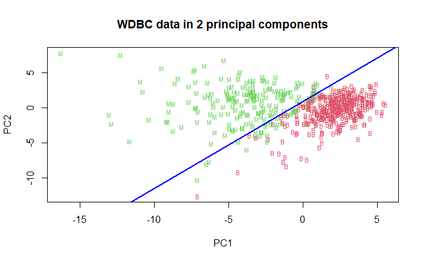

```r
model_coefficients <- coef(glm_learner$model)[colnames(data_wdbc)[-1], ]

# mozemy go zwizualizowac w pierwszych dwoch PC
pca <- prcomp(data_wdbc[, -1, with = FALSE], center = TRUE, scale = TRUE)

lineIn2PCs = (cbind(rep(1, 30), pca$rotation) %*% c(coef(glm_learner$model)[1], model_coefficients))[1:3]
plot(pca$x[, 1:2], col=data_wdbc[, as.integer(diagnosis)] + 1,
     pch=data_wdbc[, as.character(diagnosis)], cex=0.7,
     main="WDBC data in 2 principal components")
abline(coef = c(lineIn2PCs[1]/lineIn2PCs[3], lineIn2PCs[2]/lineIn2PCs[3]),
       col = 'blue', lwd = 2)
```

## Drzewa decyzyjne

Jednym z najbardziej powszechnie stosowanym modelem predykcyjnym jest **drzewo decyzyjne**. Przykłady algorytmów konstruowania drzew decyzyjnych to *ID3*, *CART* oraz *C5.0* (i nowsze wersje). Najczęściej konstruowanie drzewa decyzyjnego dzieli sie na dwie fazy. W pierwszej generuje się wstępne drzewo przez rekursywne wybieranie najlepszego podzialu danych (tzw. cięcia) na pojedynczym atrybucie. W drugiej fazie upraszcza się drzewo przez ‘*przycinanie*’ (ang. pruning) węzłów, które nie przyczyniają się znacząco do redukcji liczby popełnianych błędów. Najczęściej wykorzystywanymi miarami jakości cięcia na atrybucie są:

- information gain (bazuje na entropii) – wartość oczekiwana redukcji entropii decyzji po wykonaniu cięcia,
- gini gain – wartość oczekiwana redukcji prawdopodobieństwa popełnienia błędu przy losowaniu decyzji zgodnie z rozkladami z liści,
- discernibility gain – liczba par obiektów z różnych klas decyzyjnych, które rozróżni dane cięcie.

```r
tree_learner <- lrn("classif.rpart", cp = 0.01, minsplit = 5)

# trenowanie i ewaluacja
tree_learner$train(wdbc_task, row_ids = trainingIdx)
prediction <- tree_learner$predict(wdbc_task, row_ids = setdiff(1:nrow(data_wdbc), trainingIdx))
prediction$confusion
```

```
        truth
response   B   M
       B 124   6
       M   8  90
```

```r
acc <- msr("classif.acc")
CV <- rsmp("cv", folds = 10L)
rr <- resample(wdbc_task, tree_learner, CV)
```

```
INFO  [18:48:28.481] [mlr3] Applying learner 'classif.rpart' on task 'wdbc_dt' (iter 1/10)
INFO  [18:48:28.566] [mlr3] Applying learner 'classif.rpart' on task 'wdbc_dt' (iter 2/10)
INFO  [18:48:28.608] [mlr3] Applying learner 'classif.rpart' on task 'wdbc_dt' (iter 3/10)
INFO  [18:48:28.643] [mlr3] Applying learner 'classif.rpart' on task 'wdbc_dt' (iter 4/10)
INFO  [18:48:28.678] [mlr3] Applying learner 'classif.rpart' on task 'wdbc_dt' (iter 5/10)
INFO  [18:48:28.724] [mlr3] Applying learner 'classif.rpart' on task 'wdbc_dt' (iter 6/10)
INFO  [18:48:28.758] [mlr3] Applying learner 'classif.rpart' on task 'wdbc_dt' (iter 7/10)
INFO  [18:48:28.793] [mlr3] Applying learner 'classif.rpart' on task 'wdbc_dt' (iter 8/10)
INFO  [18:48:28.827] [mlr3] Applying learner 'classif.rpart' on task 'wdbc_dt' (iter 9/10)
INFO  [18:48:28.860] [mlr3] Applying learner 'classif.rpart' on task 'wdbc_dt' (iter 10/10)
```

```r
rr$score(acc)
```

| task_id | learner_id | resampling_id | iteration | classif.acc |
| --- | --- | --- | --- | --- |
| wdbc_dt | classif.rpart | cv | 1 | 0.9473684 |
| wdbc_dt | classif.rpart | cv | 2 | 0.9649123 |
| wdbc_dt | classif.rpart | cv | 3 | 0.8771930 |
| wdbc_dt | classif.rpart | cv | 4 | 0.8421053 |
| wdbc_dt | classif.rpart | cv | 5 | 0.8947368 |
| wdbc_dt | classif.rpart | cv | 6 | 0.8771930 |
| wdbc_dt | classif.rpart | cv | 7 | 0.8771930 |
| wdbc_dt | classif.rpart | cv | 8 | 0.9298246 |
| wdbc_dt | classif.rpart | cv | 9 | 0.9649123 |
| wdbc_dt | classif.rpart | cv | 10 | 0.9642857 |

```
Hidden columns: task, learner, resampling, prediction
```

```r
# model
tree_learner$model
```

```
n= 341

node), split, n, loss, yval, (yprob)
      * denotes terminal node

 1) root 341 116 B (0.659824047 0.340175953)
   2) worst_perimeter< 114.45 248  25 B (0.899193548 0.100806452)
     4) worst_concave_points< 0.1589 235  13 B (0.944680851 0.055319149)
       8) mean_texture< 21.315 188   1 B (0.994680851 0.005319149) *
       9) mean_texture>=21.315 47  12 B (0.744680851 0.255319149)
        18) worst_perimeter< 101.05 35   3 B (0.914285714 0.085714286) *
        19) worst_perimeter>=101.05 12   3 M (0.250000000 0.750000000)
          38) SE_compactness>=0.042475 2   0 B (1.000000000 0.000000000) *
          39) SE_compactness< 0.042475 10   1 M (0.100000000 0.900000000) *
     5) worst_concave_points>=0.1589 13   1 M (0.076923077 0.923076923) *
   3) worst_perimeter>=114.45 93   2 M (0.021505376 0.978494624) *
```

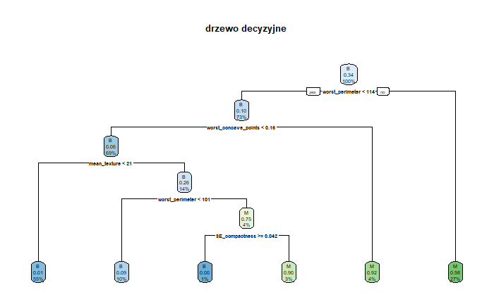

```r
rpart.plot(tree_learner$model, type = 2, digits = 2, tweak = 1.0, roundint=FALSE,
           main = 'drzewo decyzyjne')
```

## Zadanie

Proszę spróbować znaleźć optymalne wartości hiperparametrów omówionych dzisiaj modeli dla danych *wdbc*. Proszę spróbować wykorzystać w tym zadanu pakiet *mlr3tuning*.

```r
# to jest miejsce na rozwiazanie zadania:
tree_learner_optimised <- lrn("classif.rpart")
tree_learner_optimised$param_set
```

```
<ParamSet>
```

| id | class | lower | upper | nlevels | default | value |
| --- | --- | --- | --- | --- | --- | --- |
| cp | ParamDbl | 0 | 1 | Inf |  |  |
| keep_model | ParamLgl | NA | NA | 2 |  |  |
| maxcompete | ParamInt | 0 | Inf | Inf |  |  |
| maxdepth | ParamInt | 1 | 30 | 30 |  |  |
| maxsurrogate | ParamInt | 0 | Inf | Inf |  |  |
| minbucket | ParamInt | 1 | Inf | Inf |  |  |
| minsplit | ParamInt | 1 | Inf | Inf |  |  |
| surrogatestyle | ParamInt | 0 | 1 | 2 |  |  |
| usesurrogate | ParamInt | 0 | 2 | 3 |  |  |
| xval | ParamInt | 0 | Inf | Inf |  |  |

```r
tree_learner_optimised$param_set$values <- list(cp = to_tune(0, 0.5), minsplit = to_tune(1, 100))
instance = ti(
  task = wdbc_task,
  learner = tree_learner_optimised,
  resampling = rsmp("cv", folds = 10L),
  measures = msr("classif.acc"),
  terminator = trm("none")
)
instance
```

```
<TuningInstanceSingleCrit>
* State:  Not optimized
* Objective: <ObjectiveTuning:classif.rpart_on_wdbc_dt>
* Search Space:
```

| id | class | lower | upper | nlevels |
| --- | --- | --- | --- | --- |
| cp | ParamDbl | 0 | 0.5 | Inf |
| minsplit | ParamInt | 1 | 100.0 | 100 |

```
* Terminator: <TerminatorNone>
```

```r
tuner = tnr("grid_search", resolution = 5)

tuner$optimize(instance)
```

[output not shown]

| cp | minsplit | classif.acc | warnings | errors | runtime_learners | uhash |
| --- | --- | --- | --- | --- | --- | --- |
| 0.25 | 100 | 0.8928885 | 0 | 0 | 0.27 | ddda4012-1f8d-432c-848b-6fbfa785ee0f |

[output not shown]

| cp | minsplit | classif.acc | warnings | errors | runtime_learners | uhash |
| --- | --- | --- | --- | --- | --- | --- |
| 0 | 50 | 0.9227757 | 0 | 0 | 0.33 | 6e2d4642-da1b-4b24-bb02-8507c7dd0998 |

[output not shown]

| cp | minsplit | classif.acc | warnings | errors | runtime_learners | uhash |
| --- | --- | --- | --- | --- | --- | --- |
| 0.375 | 50 | 0.8928885 | 0 | 0 | 0.14 | 879a91bc-ea3c-4eec-a5bd-25f0aca257c2 |

[output not shown]

| cp | minsplit | classif.acc | warnings | errors | runtime_learners | uhash |
| --- | --- | --- | --- | --- | --- | --- |
| 0.375 | 100 | 0.8928885 | 0 | 0 | 0.15 | 9e9fee8c-9786-490d-80e1-ae70bc62898c |

[output not shown]

| cp | minsplit | classif.acc | warnings | errors | runtime_learners | uhash |
| --- | --- | --- | --- | --- | --- | --- |
| 0.25 | 25 | 0.8928885 | 0 | 0 | 0.2 | 025ace65-1334-44b8-b603-703e58597fcc |

[output not shown]

| cp | minsplit | classif.acc | warnings | errors | runtime_learners | uhash |
| --- | --- | --- | --- | --- | --- | --- |
| 0.25 | 50 | 0.8928885 | 0 | 0 | 0.14 | e10aef91-0673-4ed3-94da-f4b0f40098b6 |

[output not shown]

| cp | minsplit | classif.acc | warnings | errors | runtime_learners | uhash |
| --- | --- | --- | --- | --- | --- | --- |
| 0 | 75 | 0.9262845 | 0 | 0 | 0.44 | bf38385f-21a2-4055-a357-0fe081c12e67 |

[output not shown]

| cp | minsplit | classif.acc | warnings | errors | runtime_learners | uhash |
| --- | --- | --- | --- | --- | --- | --- |
| 0.125 | 1 | 0.8928885 | 0 | 0 | 0.25 | a1d8c044-ff0e-49f9-bf1d-28d08cb5b012 |

[output not shown]

| cp | minsplit | classif.acc | warnings | errors | runtime_learners | uhash |
| --- | --- | --- | --- | --- | --- | --- |
| 0.5 | 1 | 0.8928885 | 0 | 0 | 0.17 | fad34b67-9804-491b-b731-6aaca38a53af |

[output not shown]

| cp | minsplit | classif.acc | warnings | errors | runtime_learners | uhash |
| --- | --- | --- | --- | --- | --- | --- |
| 0.25 | 1 | 0.8928885 | 0 | 0 | 0.2 | 950c2d83-17a3-4baf-939a-7283ad8638d1 |

[output not shown]

| cp | minsplit | classif.acc | warnings | errors | runtime_learners | uhash |
| --- | --- | --- | --- | --- | --- | --- |
| 0.5 | 50 | 0.8928885 | 0 | 0 | 0.22 | d9098267-6a63-4f7c-8dee-7d95b1011437 |

[output not shown]

| cp | minsplit | classif.acc | warnings | errors | runtime_learners | uhash |
| --- | --- | --- | --- | --- | --- | --- |
| 0.125 | 50 | 0.8928885 | 0 | 0 | 0.21 | 07f981d7-8370-4ffa-80d7-1772ed0e797d |

[output not shown]

| cp | minsplit | classif.acc | warnings | errors | runtime_learners | uhash |
| --- | --- | --- | --- | --- | --- | --- |
| 0 | 100 | 0.9210213 | 0 | 0 | 0.28 | 0f370fd7-e424-4e15-aa75-e7a105594aa7 |

[output not shown]

| cp | minsplit | classif.acc | warnings | errors | runtime_learners | uhash |
| --- | --- | --- | --- | --- | --- | --- |
| 0.25 | 75 | 0.8928885 | 0 | 0 | 0.21 | b636c87d-758b-448d-bdee-75d4a442f137 |

[output not shown]

| cp | minsplit | classif.acc | warnings | errors | runtime_learners | uhash |
| --- | --- | --- | --- | --- | --- | --- |
| 0 | 1 | 0.9244674 | 0 | 0 | 0.45 | 55ed424d-32d8-4492-a081-50cdb2a9cbb9 |

[output not shown]

| cp | minsplit | classif.acc | warnings | errors | runtime_learners | uhash |
| --- | --- | --- | --- | --- | --- | --- |
| 0.125 | 100 | 0.8928885 | 0 | 0 | 0.25 | 9bacb67c-fe39-43a8-bd89-7ee3d844dcb5 |

[output not shown]

| cp | minsplit | classif.acc | warnings | errors | runtime_learners | uhash |
| --- | --- | --- | --- | --- | --- | --- |
| 0 | 25 | 0.9262845 | 0 | 0 | 0.36 | 5be9825e-2bb5-42c6-b292-5f3790f27a80 |

[output not shown]

| cp | minsplit | classif.acc | warnings | errors | runtime_learners | uhash |
| --- | --- | --- | --- | --- | --- | --- |
| 0.375 | 25 | 0.8928885 | 0 | 0 | 0.19 | 0c5349cb-85c5-4fc2-a7d1-04a44f1f3311 |

[output not shown]

| cp | minsplit | classif.acc | warnings | errors | runtime_learners | uhash |
| --- | --- | --- | --- | --- | --- | --- |
| 0.5 | 75 | 0.8928885 | 0 | 0 | 0.18 | 23662749-32f6-4306-aa42-b9e182eb1d85 |

[output not shown]

| cp | minsplit | classif.acc | warnings | errors | runtime_learners | uhash |
| --- | --- | --- | --- | --- | --- | --- |
| 0.5 | 25 | 0.8928885 | 0 | 0 | 0.21 | 7ccbe909-5839-413f-957a-c0ff72fa6eae |

[output not shown]

| cp | minsplit | classif.acc | warnings | errors | runtime_learners | uhash |
| --- | --- | --- | --- | --- | --- | --- |
| 0.125 | 75 | 0.8928885 | 0 | 0 | 0.23 | fda8f215-5150-4d72-b6a2-7640112df607 |

[output not shown]

| cp | minsplit | classif.acc | warnings | errors | runtime_learners | uhash |
| --- | --- | --- | --- | --- | --- | --- |
| 0.375 | 75 | 0.8928885 | 0 | 0 | 0.27 | d6b05ed9-f8bf-49c0-86cb-1e36505072ae |

[output not shown]

| cp | minsplit | classif.acc | warnings | errors | runtime_learners | uhash |
| --- | --- | --- | --- | --- | --- | --- |
| 0.5 | 100 | 0.8928885 | 0 | 0 | 0.14 | 29052f96-56de-4a69-b226-84b325e74015 |

[output not shown]

| cp | minsplit | classif.acc | warnings | errors | runtime_learners | uhash |
| --- | --- | --- | --- | --- | --- | --- |
| 0.125 | 25 | 0.8928885 | 0 | 0 | 0.25 | 3a1693b2-369a-4fbc-9b50-3c62a4894e37 |

[output not shown]

| cp | minsplit | classif.acc | warnings | errors | runtime_learners | uhash |
| --- | --- | --- | --- | --- | --- | --- |
| 0.375 | 1 | 0.8928885 | 0 | 0 | 0.17 | 0f6ff562-4db2-46ef-b706-75a1cb2e81d5 |

```
INFO  [18:48:50.575] [bbotk]
INFO  [18:48:50.587] [bbotk] Finished optimizing after 25 evaluation(s)
INFO  [18:48:50.590] [bbotk] Result:
```

| cp | minsplit | learner_param_vals | x_domain | classif.acc |
| --- | --- | --- | --- | --- |
| 0 | 75 |  |  | 0.9262845 |

```
INFO  [18:48:50.613] [bbotk]
```

| cp | minsplit | learner_param_vals | x_domain | classif.acc |
| --- | --- | --- | --- | --- |
| 0 | 75 |  |  | 0.9262845 |

```r
tree_learner_optimised$param_set$values = instance$result_learner_param_vals
tree_learner_optimised$wdbc_data
```

```r
tree_learner_optimised$train(wdbc_task, row_ids = trainingIdx)
prediction <- tree_learner_optimised$predict(wdbc_task, row_ids = setdiff(1:nrow(data_wdbc), trainingIdx))
prediction$confusion
```

```
        truth
response   B   M
       B 122   5
       M  10  91
```

```r
acc <- msr("classif.acc")
prediction$score(acc)
```

```
classif.acc
  0.9342105
```

```r
# model
tree_learner_optimised$model
```

```
n= 341

node), split, n, loss, yval, (yprob)
      * denotes terminal node

1) root 341 116 B (0.65982405 0.34017595)
  2) worst_perimeter< 114.45 248  25 B (0.89919355 0.10080645)
    4) worst_concave_points< 0.13595 218   8 B (0.96330275 0.03669725) *
    5) worst_concave_points>=0.13595 30  13 M (0.43333333 0.56666667) *
  3) worst_perimeter>=114.45 93   2 M (0.02150538 0.97849462) *
```

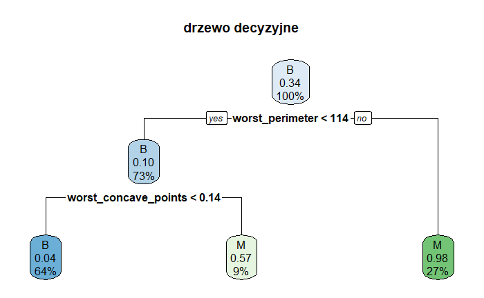

```r
rpart.plot(tree_learner_optimised$model, type = 2, digits = 2, tweak = 1.0, roundint=FALSE,
           main = 'drzewo decyzyjne')
```

```r
acc <- msr("classif.acc")
CV <- rsmp("cv", folds = 10L)
rr <- resample(wdbc_task, tree_learner_optimised, CV)
```

```
INFO  [18:48:50.905] [mlr3] Applying learner 'classif.rpart' on task 'wdbc_dt' (iter 1/10)
INFO  [18:48:50.953] [mlr3] Applying learner 'classif.rpart' on task 'wdbc_dt' (iter 2/10)
INFO  [18:48:51.010] [mlr3] Applying learner 'classif.rpart' on task 'wdbc_dt' (iter 3/10)
INFO  [18:48:51.062] [mlr3] Applying learner 'classif.rpart' on task 'wdbc_dt' (iter 4/10)
INFO  [18:48:51.107] [mlr3] Applying learner 'classif.rpart' on task 'wdbc_dt' (iter 5/10)
INFO  [18:48:51.158] [mlr3] Applying learner 'classif.rpart' on task 'wdbc_dt' (iter 6/10)
INFO  [18:48:51.215] [mlr3] Applying learner 'classif.rpart' on task 'wdbc_dt' (iter 7/10)
INFO  [18:48:51.275] [mlr3] Applying learner 'classif.rpart' on task 'wdbc_dt' (iter 8/10)
INFO  [18:48:51.329] [mlr3] Applying learner 'classif.rpart' on task 'wdbc_dt' (iter 9/10)
INFO  [18:48:51.410] [mlr3] Applying learner 'classif.rpart' on task 'wdbc_dt' (iter 10/10)
```

```r
rr$score(acc)
```

| task_id | learner_id | resampling_id | iteration | classif.acc |
| --- | --- | --- | --- | --- |
| wdbc_dt | classif.rpart | cv | 1 | 0.9122807 |
| wdbc_dt | classif.rpart | cv | 2 | 0.9122807 |
| wdbc_dt | classif.rpart | cv | 3 | 0.9298246 |
| wdbc_dt | classif.rpart | cv | 4 | 0.8771930 |
| wdbc_dt | classif.rpart | cv | 5 | 0.8596491 |
| wdbc_dt | classif.rpart | cv | 6 | 0.9298246 |
| wdbc_dt | classif.rpart | cv | 7 | 0.9122807 |
| wdbc_dt | classif.rpart | cv | 8 | 0.9122807 |
| wdbc_dt | classif.rpart | cv | 9 | 0.9649123 |
| wdbc_dt | classif.rpart | cv | 10 | 0.9464286 |

```
Hidden columns: task, learner, resampling, prediction
```

```r
instance$result_learner_param_vals
```

```
$cp
[1] 0

$minsplit
[1] 75
```

[output not shown]